# Biostat 214 2024 Assignment 1

Name: Kaileiani Louie

## General Instructions

Please attempt all exercises individually.

Always use R’s builtin documentation for help as needed. Do not rush to search the internet, you will get many bad and/or irrelevant answers.

Write your solution below each exercise and test that it works (i.e. execute it). Always feel free to run any number of tests on your code, but only submit what is explicitly requested. If you wish, you can always keep a draft with extra code or notes for your own reference.

Do not delete any existing text, code, or comments. Do not alter the YAML header (the lines at the top between the set of 3 dashes `---`) or the file may not render correctly.

Comment lines with “@grade” are used to a) show you how many points are assigned to each exercise, and b) add up grades. Do not delete or modify them.

If you have any questions, please make a note and bring them up in class next week. No question is too big or too small.

*Take note of the CLE deadline. Uploads are automatically disabled past the deadline and no assignments are accepted via email.* When you are done answering all questions, render this document to HTML and *submit both this .qmd and the output .html file on the CLE*.

Each assignment can get a max score of 100%. Bonus questions can help make up for lost points in other questions, but can’t raise your score above 100%.

## Assignment 1 Instructions

In all exercises below you are asked to write a function and test it.

Note that a minimal documentation of each function you are expected to write is included using the roxygen format that includes the function title, argument description and information on the returned value.

This is to help you learn the basics of roxygen and emphasize that you should make it a habit to document all functions you write at the time you write them.

## 1. Single argument

1A. Write a function named `add10()` that accepts a numeric vector `x` and adds 10 to each element.

Remember that R does not enforce class or type of input arguments. In the instructions, “numeric vector`x`” is to help you understand with what kind of input your function should work. You are not asked to write tests check or ensure the input is numeric. The same applied in all exercises below.

```r
#' Add 10 to vector
#'
#' @param x Numeric vector
#'
#' @return Numeric vector


add10 <- function(x) {
  return(x + 10)
}
```

1B. Test your function:

```r
x <- c(1, 2, 3, 4, 5)

add10(x)
```

```
[1] 11 12 13 14 15
```

1C. Test what happens if your input is *not* numeric (i.e. neither double nor integer):

```r
x <- c("item 1", "item 2", "item 3", "item 4", "item 5")

add10(x)
```

```
Error in x + 10: non-numeric argument to binary operator
```

## 2. Two arguments

2A. Write a function named `addk()` that accepts a numeric vector `x` and an integer `k` and returns the vector after adding `k` to each element.

```r
#' Add k to vector
#'
#' @param x Numeric vector
#' @param k Integer to be added to `x`
#'
#' @return Numeric vector


addk <- function(x, k) {
  return(x + k)
}
```

2B. Test your function:

```r
x <- c(1, 2, 3, 4, 5)
k <- 20

addk(x, k)
```

```
[1] 21 22 23 24 25
```

## 3. Two arguments with default

3A. Write a function named `dividebyh()` that accepts a numeric vector `x` and a decimal `h` with default value equal to 2.3 and returns a numeric vector after dividing each element of `x` by `h`.

```r
#' Divide by h
#'
#' @param x Numeric vector
#' @param h Decimal to divide `x` by
#'
#' @return Numeric vector


dividebyh <- function(x, h = 2.3) {
  return(x / h)
}
```

3B. Test your function using default `h`:

```r
x <- c(2.3, 4.6, 6.9, 9.2, 11.5)

dividebyh(x)
```

```
[1] 1 2 3 4 5
```

3C. Test your function by providing a different value of `h` of your choice:

```r
x <- c(1.1, 2.2, 3.3, 4.4)

dividebyh(x, 1.1)
```

```
[1] 1 2 3 4
```

## 4. Two arguments with error

4A. Write a function named `bmi()` that accepts two numeric vectors, `weight` and `height` and returns the bmi for each pair of input values. If any value in `weight` is non-positive, the function should stop with an error message: “Only positive weight values are allowed.” If any value in `height` is non-positive, the function should stop with an error message: “Only positive height values are allowed.”

```r
#' Calculate BMI
#'
#' Calculates Body Mass Index (BMI) from weight and height
#'
#' @param weight Numeric vector: Weight in kg
#' @param height Numeric vector: Height in meters
#'
#' @return Numeric vector


bmi <- function(weight, height) {
  if (!is.numeric(weight) || any(weight <= 0)) {
    stop("Only positive weight values are allowed.")
  }

  if (!is.numeric(height) || any(height <= 0)) {
    stop("Only positive height values are allowed.")
  }

  bmi_values <- weight / (height ^ 2)

  return(bmi_values)
}
```

4B. Test your function using weight and height vectors of length 3 with positive values only:

```r
weight <- c(70, 80, 60) #kg
height <- c(1.75, 1.80, 1.85) #m

bmi(weight, height)
```

```
[1] 22.85714 24.69136 17.53104
```

4C. Test your function using weight and height vectors of length 3 including a single negative value in `height`:

```r
weight <- c(70, 80, 60) #kg
height <- c(1.75, 1.80, -1.85) #m

bmi(weight, height)
```

```
Error in bmi(weight, height): Only positive height values are allowed.
```

## 5. Custom scatter plot

5A. Write a custom scatter plot function named `scatter()` that accepts the following arguments:

- `x` numeric vector
- `y` numeric vector
- `marker_color` that defaults to “magenta”
- Additional arguments `...`

and plots a scatter plot using `plot()`, with points colored as defined by `marker_color` and where the additional arguments are passed to `plot()`.

```r
#' Custom scatter plot
#'
#' @param x Numeric vector
#' @param y Numeric vector
#' @param marker_color Color of the markers
#' @param ... Additional arguments passed to `plot()`
#'
#' @return None


scatter <- function(x, y, marker_color = "magenta", ...) {
  plot(x, y, col = marker_color, pch = 16, ...)
}
```

5B. Test your function using the default `marker_color`:

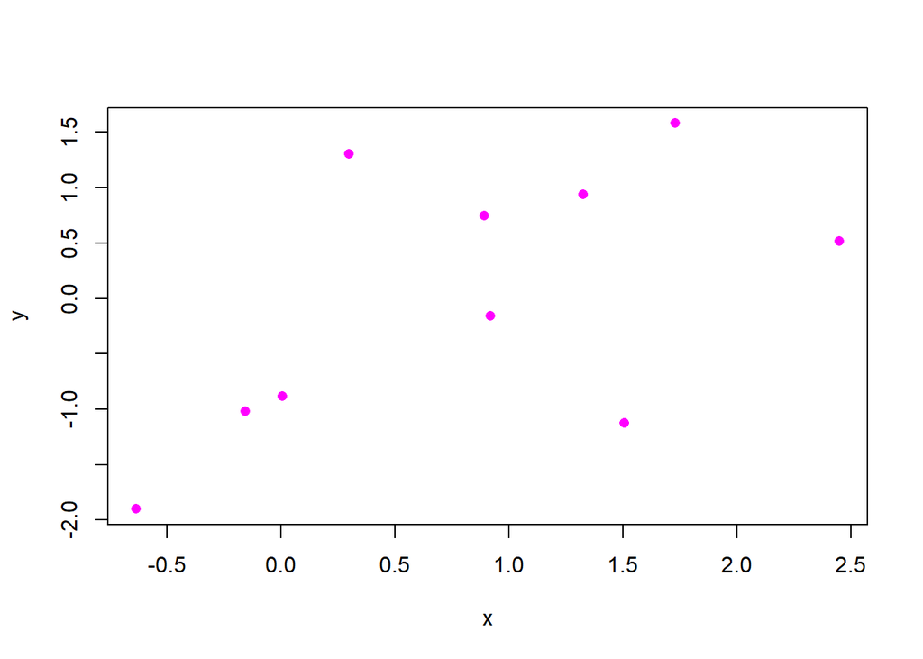

```r
x <- rnorm(10)
y <- rnorm(10)

scatter(x, y)
```

5C. Test your function using a different `marker_color`:

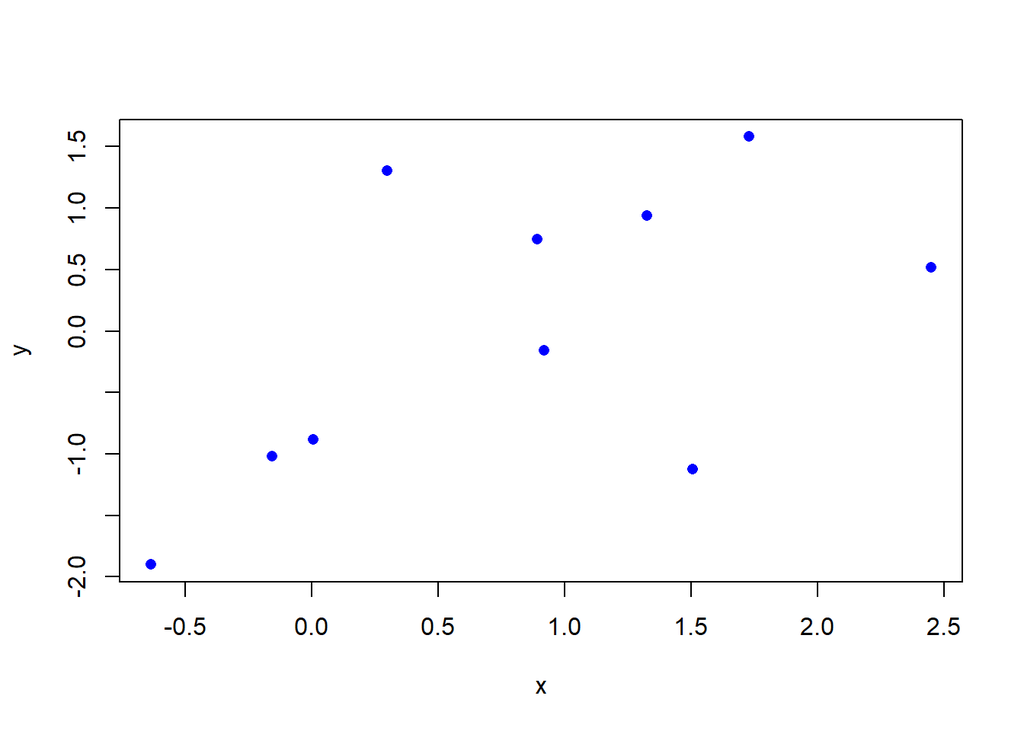

```r
scatter(x, y, marker_color = "blue")
```

## 6. Function with warning

6A. Write a function named `squared()` that:

- accepts a vector `x`
- returns a vector with the square of each element of `x`
- produces a warning if any values of `x` are negative that prints: “Negative values found!”

```r
#' Square a vector
#'
#' Squares a vector and produces a warning if any negative values are found
#'
#' @param x Numeric vector
#'
#' @return Numeric vector


squared <- function(x) {
  if (any(x < 0)) {
    warning("Negative values found!")
  }

  return(x^2)
}
```

6B. Test your function with a vector that contains no negative values:

```r
x <- c(1, 2, 3, 4, 5)

squared(x)
```

```
[1]  1  4  9 16 25
```

6C. Test your function with a vector that contains negative values:

```r
x <- c(-1, 2, -3, 4, -5)

squared(x)
```

```
[1]  1  4  9 16 25
```

## 7. Matching arguments

7A. Write a function named `patient_info()` that accepts two arguments:

- `mrn` integer
- `hospital` character with only allowed values “Parnassus”, “Mt_Zion”, “Mission_Bay”, “SFGH”

and prints “MRN: mrn; Hospital: hospital” to the console.

```r
#' Patient information
#'
#' Prints patient information to the console
#'
#' @param mrn Integer: Medical Record Number
#' @param hospital Character: "Parnassus", "Mt_Zion", "Mission_Bay", or "SFGH": Hospital name
#'
#' @return None


patient_info <- function(mrn, hospital) {
  allowed_hospitals <- c("Parnassus", "Mt_Zion", "Mission_Bay", "SFGH")
  if (!hospital %in% allowed_hospitals) {
    stop("Hospital does not match")
  }

  cat("MRN:", mrn, "; Hospital:", hospital)
}
```

7B. Test your function with a valid hospital:

```r
mrn <- as.integer(7412)
hospital <- "Parnassus"

patient_info(mrn, hospital)
```

```
MRN: 7412 ; Hospital: Parnassus
```

7C. Test your function with an invalid hospital:

```r
rn <- as.integer(7412)
hospital <- "Oakland"

patient_info(mrn, hospital)
```

```
Error in patient_info(mrn, hospital): Hospital does not match
```

## 8. Summarize data.frame (Bonus question)

8A. Write a function named `summarize` that has a single argument `x`.

It should accept a data.frame and:

- Print the statement `Input consists of N rows by P columns.`, replacing `N` and `P` with the appropriate number of rows and columns,
- Return a list with two elements named “n_rows” and “n_columns” that contain the respective numbers.

```r
#' Summarize data.frame
#'
#' Summarizes a data.frame by printing the number of rows and columns
#'
#' @param x Data frame
#'
#' @return List with two elements: n_rows and n_cols


summarize <- function(x) {
  n_rows <- nrow(x)
  n_columns <- ncol(x)

  cat("Input consists of", n_rows, "rows by", n_columns, "columns.", "\n")

  return(list(n_rows = n_rows, n_columns = n_columns))
}
```

8B. Test your function on the `iris` data frame and assign the output to `iris_summary`:

```r
iris_summary <- summarize(iris)
```

```
Input consists of 150 rows by 5 columns.
```

```r
iris_summary
```

```
$n_rows
[1] 150

$n_columns
[1] 5
```

## Submit

When you have finished all exercises, compile the document into HTML.  
Double check you have completed all exercises and submit both the .qmd and .html files through the CLE.